# 1.A. Refer above table and find the joint probability of the people who planned to purchase and actually placed an order

```python
#Find out the outliers
datay = teamwiseperformance[['gameswon','Drawngames','Lostgames']];

y = np.abs(stats.zscore(datay))
```

```python
threshold = 3
np.where(y > threshold)
```

```
(array([ 0,  1, 45, 59], dtype=int64), array([0, 0, 1, 2], dtype=int64))
```

```python
teamwiseperformance.iloc[[0,1,45,59]]
```

|  | Team | TeamLaunch | PlayedGames | HighestPositionHeld | gameswon | Drawngames | Lostgames | Tournamentchampionship | Tournamentrunnerup |
| --- | --- | --- | --- | --- | --- | --- | --- | --- | --- |
| 0 | T1 | 1929.0 | 2762.0 | 1 | 59.6307 | 19.9855 | 20.3838 | 38.3721 | 26.7442 |
| 1 | T2 | 1929.0 | 2762.0 | 1 | 57.2411 | 20.7458 | 22.0130 | 29.0698 | 29.0698 |
| 45 | T46 | NaN | 114.0 | 9 | 22.8070 | 38.5965 | 38.5965 | NaN | NaN |
| 59 | T60 | NaN | 30.0 | 15 | 16.6667 | 13.3333 | 70.0000 | NaN | NaN |

```python
#Top 7 teams
top7 = teamwiseperformance.sort_values(['gameswon'],ascending=[False]).head(7)
top7
```

|  | Team | TeamLaunch | PlayedGames | HighestPositionHeld | gameswon | Drawngames | Lostgames | Tournamentchampionship | Tournamentrunnerup |
| --- | --- | --- | --- | --- | --- | --- | --- | --- | --- |
| 0 | T1 | 1929.0 | 2762.0 | 1 | 59.6307 | 19.9855 | 20.3838 | 38.3721 | 26.7442 |
| 1 | T2 | 1929.0 | 2762.0 | 1 | 57.2411 | 20.7458 | 22.0130 | 29.0698 | 29.0698 |
| 2 | T3 | 1929.0 | 2614.0 | 1 | 47.4751 | 22.8768 | 29.6480 | 12.5000 | 10.0000 |
| 3 | T4 | NaN | 2664.0 | 1 | 44.5571 | 23.1231 | 32.3198 | 7.3171 | 7.3171 |
| 4 | T5 | 1929.0 | 2762.0 | 1 | 43.7726 | 22.9182 | 33.3092 | 9.3023 | 8.1395 |
| 20 | T21 | NaN | 646.0 | 2 | 41.1765 | 26.6254 | 32.1981 | NaN | 5.8824 |
| 5 | T6 | NaN | 2408.0 | 1 | 41.1130 | 22.0515 | 36.8355 | 1.3699 | 5.4795 |

```python
#Team with best performance
teamwiseperformance[(teamwiseperformance.gameswon==teamwiseperformance.gameswon.max()) & (teamwiseperformance.Lostgames==teamwiseperformance.Lostgames.min() )]
```

|  | Team | TeamLaunch | PlayedGames | HighestPositionHeld | gameswon | Drawngames | Lostgames | Tournamentchampionship | Tournamentrunnerup |
| --- | --- | --- | --- | --- | --- | --- | --- | --- | --- |
| 0 | T1 | 1929.0 | 2762.0 | 1 | 59.6307 | 19.9855 | 20.3838 | 38.3721 | 26.7442 |

```python
data[(data.PlayedGames==data.PlayedGames.max())] # teams wit highest targets in the dataset
```

|  | Team | Tournament | Score | PlayedGames | WonGames | DrawnGames | LostGames | BasketScored | BasketGiven | TournamentChampion | Runnerup | TeamLaunch | HighestPositionHeld |
| --- | --- | --- | --- | --- | --- | --- | --- | --- | --- | --- | --- | --- | --- |
| 0 | T1 | 86 | 4385.0 | 2762.0 | 1647.0 | 552.0 | 563.0 | 5947.0 | 3140.0 | 33.0 | 23.0 | 1929.0 | 1 |
| 1 | T2 | 86 | 4262.0 | 2762.0 | 1581.0 | 573.0 | 608.0 | 5900.0 | 3114.0 | 25.0 | 25.0 | 1929.0 | 1 |
| 4 | T5 | 86 | 3368.0 | 2762.0 | 1209.0 | 633.0 | 920.0 | 4631.0 | 3700.0 | 8.0 | 7.0 | 1929.0 | 1 |

```python
data[(data.PlayedGames==data.PlayedGames.nlargest(4)[3])] #finding other teams with best targets as above are outliers
```

|  | Team | Tournament | Score | PlayedGames | WonGames | DrawnGames | LostGames | BasketScored | BasketGiven | TournamentChampion | Runnerup | TeamLaunch | HighestPositionHeld |
| --- | --- | --- | --- | --- | --- | --- | --- | --- | --- | --- | --- | --- | --- |
| 3 | T4 | 82 | 3386.0 | 2664.0 | 1187.0 | 616.0 | 861.0 | 4398.0 | 3469.0 | 6.0 | 6.0 | NaN | 1 |

```python
(data.sort_values(['PlayedGames'],ascending=[True])).head(3) #Low performing team or with low targets
```

|  | Team | Tournament | Score | PlayedGames | WonGames | DrawnGames | LostGames | BasketScored | BasketGiven | TournamentChampion | Runnerup | TeamLaunch | HighestPositionHeld |
| --- | --- | --- | --- | --- | --- | --- | --- | --- | --- | --- | --- | --- | --- |
| 59 | T60 | 1 | 14.0 | 30.0 | 5.0 | 4.0 | 21.0 | 34.0 | 65.0 | NaN | NaN | NaN | 15 |
| 57 | T58 | 1 | 22.0 | 30.0 | 7.0 | 8.0 | 15.0 | 37.0 | 57.0 | NaN | NaN | NaN | 16 |
| 58 | T59 | 1 | 19.0 | 30.0 | 7.0 | 5.0 | 18.0 | 51.0 | 85.0 | NaN | NaN | NaN | 16 |

```python
#Oldest teams with low performance
sorted=teamwiseperformance.loc[teamwiseperformance['TeamLaunch'] < 1931].sort_values(['gameswon'],ascending=[True])
sorted.head(10)
```

|  | Team | TeamLaunch | PlayedGames | HighestPositionHeld | gameswon | Drawngames | Lostgames | Tournamentchampionship | Tournamentrunnerup |
| --- | --- | --- | --- | --- | --- | --- | --- | --- | --- |
| 51 | T52 | 1929.0 | 72.0 | 6 | 29.1667 | 19.4444 | 51.3889 | NaN | NaN |
| 13 | T14 | 1929.0 | 1428.0 | 2 | 31.7227 | 23.5294 | 44.7479 | NaN | 2.2727 |
| 44 | T45 | 1929.0 | 130.0 | 3 | 33.0769 | 16.1538 | 50.7692 | NaN | NaN |
| 53 | T54 | 1929.0 | 54.0 | 8 | 33.3333 | 11.1111 | 55.5556 | NaN | NaN |
| 6 | T7 | 1929.0 | 2626.0 | 3 | 36.1005 | 23.1531 | 40.7464 | NaN | NaN |
| 7 | T8 | 1929.0 | 2302.0 | 1 | 37.5326 | 25.0652 | 37.4023 | 2.8571 | 4.2857 |
| 4 | T5 | 1929.0 | 2762.0 | 1 | 43.7726 | 22.9182 | 33.3092 | 9.3023 | 8.1395 |
| 2 | T3 | 1929.0 | 2614.0 | 1 | 47.4751 | 22.8768 | 29.6480 | 12.5000 | 10.0000 |
| 1 | T2 | 1929.0 | 2762.0 | 1 | 57.2411 | 20.7458 | 22.0130 | 29.0698 | 29.0698 |
| 0 | T1 | 1929.0 | 2762.0 | 1 | 59.6307 | 19.9855 | 20.3838 | 38.3721 | 26.7442 |

```python
#old teams with low targets
sorted=(data.sort_values(['PlayedGames'],ascending=[True]))

sorted[(sorted.TeamLaunch==sorted.TeamLaunch.min())].head(5)
```

|  | Team | Tournament | Score | PlayedGames | WonGames | DrawnGames | LostGames | BasketScored | BasketGiven | TournamentChampion | Runnerup | TeamLaunch | HighestPositionHeld |
| --- | --- | --- | --- | --- | --- | --- | --- | --- | --- | --- | --- | --- | --- |
| 53 | T54 | 3 | 42.0 | 54.0 | 18.0 | 6.0 | 30.0 | 97.0 | 131.0 | NaN | NaN | 1929.0 | 8 |
| 51 | T52 | 4 | 56.0 | 72.0 | 21.0 | 14.0 | 37.0 | 153.0 | 184.0 | NaN | NaN | 1929.0 | 6 |
| 44 | T45 | 7 | 107.0 | 130.0 | 43.0 | 21.0 | 66.0 | 227.0 | 308.0 | NaN | NaN | 1929.0 | 3 |
| 13 | T14 | 44 | 1416.0 | 1428.0 | 453.0 | 336.0 | 639.0 | 1843.0 | 2368.0 | NaN | 1.0 | 1929.0 | 2 |
| 7 | T8 | 70 | 2573.0 | 2302.0 | 864.0 | 577.0 | 861.0 | 3228.0 | 3230.0 | 2.0 | 3.0 | 1929.0 | 1 |

```python
#teams with most drwan games can do better

teamwiseperformance.sort_values(['Drawngames'],ascending=[False]).head(3)
```

|  | Team | TeamLaunch | PlayedGames | HighestPositionHeld | gameswon | Drawngames | Lostgames | Tournamentchampionship | Tournamentrunnerup |
| --- | --- | --- | --- | --- | --- | --- | --- | --- | --- |
| 45 | T46 | NaN | 114.0 | 9 | 22.8070 | 38.5965 | 38.5965 | NaN | NaN |
| 48 | T49 | NaN | 80.0 | 19 | 23.7500 | 30.0000 | 46.2500 | NaN | NaN |
| 55 | T56 | NaN | 38.0 | 17 | 21.0526 | 28.9474 | 50.0000 | NaN | NaN |

```python
# Recommended teams

teamlist=['T22','T13','T46','T20','T29','T11','T8','T3','T35','T2','T45','T14','T40','T30','T19','T18']

recommendedteams=pd.DataFrame(columns=teamwiseperformance.columns);

for i in teamlist:
       if i in teamwiseperformance.Team.values:
            recommendedteams = pd.concat([recommendedteams,teamwiseperformance[ teamwiseperformance.Team==i]], ignore_index=True)


recommendedteams.sort_values('gameswon',ascending=False)
```

|  | Team | TeamLaunch | PlayedGames | HighestPositionHeld | gameswon | Drawngames | Lostgames | Tournamentchampionship | Tournamentrunnerup |
| --- | --- | --- | --- | --- | --- | --- | --- | --- | --- |
| 9 | T2 | 1929.0 | 2762.0 | 1 | 57.2411 | 20.7458 | 22.013 | 29.0698 | 29.0698 |
| 7 | T3 | 1929.0 | 2614.0 | 1 | 47.4751 | 22.8768 | 29.648 | 12.5 | 10.0 |
| 6 | T8 | 1929.0 | 2302.0 | 1 | 37.5326 | 25.0652 | 37.4023 | 2.8571 | 4.2857 |
| 5 | T11 | NaN | 1530.0 | 1 | 36.7974 | 25.6209 | 37.5817 | 2.2222 | 11.1111 |
| 15 | T18 | NaN | 1192.0 | 3 | 34.2282 | 24.4966 | 41.2752 | NaN | NaN |
| 14 | T19 | NaN | 988.0 | 3 | 33.7045 | 25.9109 | 40.3846 | NaN | NaN |
| 3 | T20 | NaN | 1096.0 | 2 | 33.4854 | 22.0803 | 44.4343 | NaN | 3.0303 |
| 10 | T45 | 1929.0 | 130.0 | 3 | 33.0769 | 16.1538 | 50.7692 | NaN | NaN |
| 4 | T29 | NaN | 380.0 | 6 | 32.8947 | 21.3158 | 45.7895 | NaN | NaN |
| 11 | T14 | 1929.0 | 1428.0 | 2 | 31.7227 | 23.5294 | 44.7479 | NaN | 2.2727 |
| 1 | T13 | NaN | 1466.0 | 4 | 31.5825 | 26.1937 | 42.2237 | NaN | NaN |
| 8 | T35 | NaN | 334.0 | 4 | 30.8383 | 23.6527 | 45.509 | NaN | NaN |
| 0 | T22 | NaN | 742.0 | 6 | 29.3801 | 23.5849 | 47.035 | NaN | NaN |
| 13 | T30 | NaN | 402.0 | 6 | 28.1095 | 23.6318 | 48.2587 | NaN | NaN |
| 12 | T40 | NaN | 186.0 | 8 | 26.8817 | 24.7312 | 48.3871 | NaN | NaN |
| 2 | T46 | NaN | 114.0 | 9 | 22.807 | 38.5965 | 38.5965 | NaN | NaN |

Please include any improvements or suggestions to the association management on quality, quantity, variety, velocity, veracity etc. on the data points collected by the association to perform a better data analysis in future. At-least 1 suggestion for each point.

Volume - Information about all matches conducted since 90s will help better for a detailed analysis.

Velocity - Information about several matches held across the years can help

Variety - Player informations, Tournaments detauils can also help

Veracity - Dates and months should be availabale with launch year

Value - A large scope of data collection for detailed game, team performace and player performance is there

# Company X is a EU online publisher focusing on the startups industry. The company specifically reports on the business related to technology news, analysis of emerging trends and profiling of new tech businesses and products. Their event i.e. Startup Battlefield is the world’s pre-eminent startup competition. Startup Battlefield features 15-30 top early stage startups pitching top judges in front of a vast live audience,present in person and online

```python
#Read the CSV file
df = pd.read_csv("C:\\Users\\DELL\\Downloads\\CompanyX_EU.csv")
```

```python
df.head()
```

|  | Startup | Product | Funding | Event | Result | OperatingState |
| --- | --- | --- | --- | --- | --- | --- |
| 0 | 2600Hz | 2600hz.com | NaN | Disrupt SF 2013 | Contestant | Operating |
| 1 | 3DLT | 3dlt.com | $630K | Disrupt NYC 2013 | Contestant | Closed |
| 2 | 3DPrinterOS | 3dprinteros.com | NaN | Disrupt SF 2016 | Contestant | Operating |
| 3 | 3Dprintler | 3dprintler.com | $1M | Disrupt NY 2016 | Audience choice | Operating |
| 4 | 42 Technologies | 42technologies.com | NaN | Disrupt NYC 2013 | Contestant | Operating |

```python
#Check the datatypes of each attribute.

df.dtypes
```

```
Startup           object
Product           object
Funding           object
Event             object
Result            object
OperatingState    object
dtype: object
```

```python
#Check for null values in the attributes.
df.isnull()
```

|  | Startup | Product | Funding | Event | Result | OperatingState |
| --- | --- | --- | --- | --- | --- | --- |
| 0 | False | False | True | False | False | False |
| 1 | False | False | False | False | False | False |
| 2 | False | False | True | False | False | False |
| 3 | False | False | False | False | False | False |
| 4 | False | False | True | False | False | False |
| ... | ... | ... | ... | ... | ... | ... |
| 657 | False | False | False | False | False | False |
| 658 | False | False | False | False | False | False |
| 659 | False | False | False | False | False | False |
| 660 | False | False | False | False | False | False |
| 661 | False | False | False | False | False | False |

662 rows × 6 columns

```python
# Drop the null values.
df.dropna(inplace = True)
df
```

|  | Startup | Product | Funding | Event | Result | OperatingState |
| --- | --- | --- | --- | --- | --- | --- |
| 1 | 3DLT | 3dlt.com | $630K | Disrupt NYC 2013 | Contestant | Closed |
| 3 | 3Dprintler | 3dprintler.com | $1M | Disrupt NY 2016 | Audience choice | Operating |
| 5 | 5to1 | 5to1.com | $19.3M | TC50 2009 | Contestant | Acquired |
| 6 | 8 Securities | 8securities.com | $29M | Disrupt Beijing 2011 | Finalist | Operating |
| 10 | AdhereTech | adheretech.com | $1.8M | Hardware Battlefield 2014 | Contestant | Operating |
| ... | ... | ... | ... | ... | ... | ... |
| 657 | Zivity | zivity.com | $8M | TC40 2007 | Contestant | Operating |
| 658 | Zmorph | zmorph3d.com | $1M | - | Audience choice | Operating |
| 659 | Zocdoc | zocdoc.com | $223M | TC40 2007 | Contestant | Operating |
| 660 | Zula | zulaapp.com | $3.4M | Disrupt SF 2013 | Audience choice | Operating |
| 661 | Zumper | zumper.com | $31.5M | Disrupt SF 2012 | Finalist | Operating |

446 rows × 6 columns

```python
df.isnull()
```

|  | Startup | Product | Funding | Event | Result | OperatingState |
| --- | --- | --- | --- | --- | --- | --- |
| 1 | False | False | False | False | False | False |
| 3 | False | False | False | False | False | False |
| 5 | False | False | False | False | False | False |
| 6 | False | False | False | False | False | False |
| 10 | False | False | False | False | False | False |
| ... | ... | ... | ... | ... | ... | ... |
| 657 | False | False | False | False | False | False |
| 658 | False | False | False | False | False | False |
| 659 | False | False | False | False | False | False |
| 660 | False | False | False | False | False | False |
| 661 | False | False | False | False | False | False |

446 rows × 6 columns

```python
dfa = df.copy()
#Converting the column entries to string
dfa["Funding"] = df["Funding"].astype(str)

#Removing dolar symbol '$' from the column entries
dfa["Funding"] = dfc["Funding"].str.replace('$','')
```

```python
def conversion(currency):

    #Reference dictionary for key value pair defining symbol to multiplier value
    d = {'K': 1000,'M': 1000000,'B': 1000000000}

    if currency[-1] in d:
        # separate out the K, M, or B
        number, multiplier = currency[:-1], currency[-1]
        return int(float(number) * d[multiplier])
    else:
        return float(currency)
```

```python
dfa["Funding"] = dfa["Funding"].apply(conversion)
```

```python
dfa.dtypes
```

```
Startup           object
Product           object
Funding            int64
Event             object
Result            object
OperatingState    object
dtype: object
```

```python
dfa["Funds_In_Millions"] = dfa["Funding"]/1e6
dfa
```

|  | Startup | Product | Funding | Event | Result | OperatingState | Funds_In_Millions |
| --- | --- | --- | --- | --- | --- | --- | --- |
| 1 | 3DLT | 3dlt.com | 630000 | Disrupt NYC 2013 | Contestant | Closed | 0.63 |
| 3 | 3Dprintler | 3dprintler.com | 1000000 | Disrupt NY 2016 | Audience choice | Operating | 1.00 |
| 5 | 5to1 | 5to1.com | 19300000 | TC50 2009 | Contestant | Acquired | 19.30 |
| 6 | 8 Securities | 8securities.com | 29000000 | Disrupt Beijing 2011 | Finalist | Operating | 29.00 |
| 10 | AdhereTech | adheretech.com | 1800000 | Hardware Battlefield 2014 | Contestant | Operating | 1.80 |
| ... | ... | ... | ... | ... | ... | ... | ... |
| 657 | Zivity | zivity.com | 8000000 | TC40 2007 | Contestant | Operating | 8.00 |
| 658 | Zmorph | zmorph3d.com | 1000000 | - | Audience choice | Operating | 1.00 |
| 659 | Zocdoc | zocdoc.com | 223000000 | TC40 2007 | Contestant | Operating | 223.00 |
| 660 | Zula | zulaapp.com | 3400000 | Disrupt SF 2013 | Audience choice | Operating | 3.40 |
| 661 | Zumper | zumper.com | 31500000 | Disrupt SF 2012 | Finalist | Operating | 31.50 |

446 rows × 7 columns

```python
dfa.head(10)
```

|  | Startup | Product | Funding | Event | Result | OperatingState | Funds_In_Millions |
| --- | --- | --- | --- | --- | --- | --- | --- |
| 1 | 3DLT | 3dlt.com | 630000 | Disrupt NYC 2013 | Contestant | Closed | 0.6300 |
| 3 | 3Dprintler | 3dprintler.com | 1000000 | Disrupt NY 2016 | Audience choice | Operating | 1.0000 |
| 5 | 5to1 | 5to1.com | 19300000 | TC50 2009 | Contestant | Acquired | 19.3000 |
| 6 | 8 Securities | 8securities.com | 29000000 | Disrupt Beijing 2011 | Finalist | Operating | 29.0000 |
| 10 | AdhereTech | adheretech.com | 1800000 | Hardware Battlefield 2014 | Contestant | Operating | 1.8000 |
| 11 | AdRocket | adrocket.com | 1000000 | TC50 2008 | Contestant | Closed | 1.0000 |
| 13 | Agrilyst | agrilyst.com | 1000000 | Disrupt SF 2015 | Winner | Operating | 1.0000 |
| 14 | Aiden | aiden.ai | 750000 | Disrupt London 2016 | Contestant | Operating | 0.7500 |
| 15 | AirBoxLab | foobot.io | 17900 | Hardware Battlefield 2014 | Contestant | Operating | 0.0179 |
| 16 | Aircall | aircall.io | 11600000 | Disrupt SF 2015 | Contestant | Operating | 11.6000 |

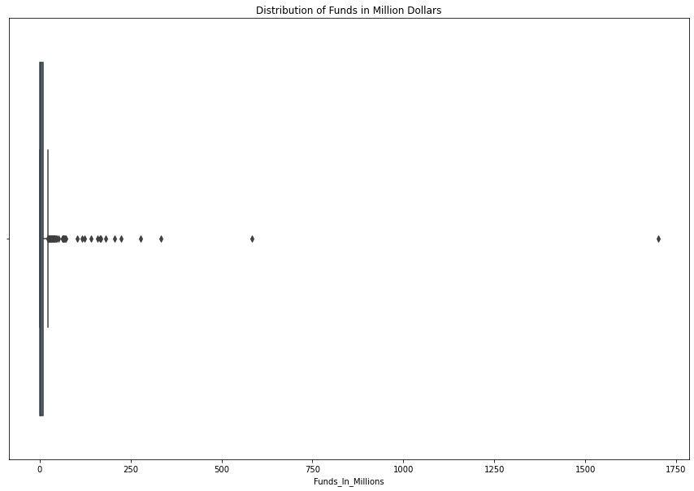

```python
#Plot box plot for funds in million
fig, ax = plt.subplots(figsize=(15,10))
sns.boxplot(x='Funds_In_Millions',data=dfa).set_title("Distribution of Funds in Million Dollars");
```

```python
dfb = dfa.describe()['Funding']
dfb
```

```
count    4.460000e+02
mean     1.724149e+07
std      9.048371e+07
min      5.000000e+03
25%      7.452500e+05
50%      2.200000e+06
75%      9.475000e+06
max      1.700000e+09
Name: Funding, dtype: float64
```

```python
t1 = np.quantile(dfb, 0.35)

t3 = np.quantile(dfb, 0.85)
med = np.median(dfb)

iqr = t3-t1

upper_fence = t3+(1.5*iqr)
lower_fence = t1-(1.5*iqr)
print(iqr, upper_fence, lower_fence)
print("The value of the upper fence of the box plot = %1.4f" %upper_fence)
```

```
85421711.4892515 214954166.22312874 -126732679.73387724
The value of the upper fence of the box plot = 214954166.2231
```

```python
#Another way
outliers = dfb[(dfb <= lower_fence) | (dfb >= upper_fence)]
print('The following are the outliers in the boxplot:',outliers)
```

```
The following are the outliers in the boxplot: max    1.700000e+09
Name: Funding, dtype: float64
```

```python
#Remove values greater than upper fence or outliers

Fund_without_o = dfa[dfa["Funds_In_Millions"] <= upper_fence]
Fund_without_o
```

|  | Startup | Product | Funding | Event | Result | OperatingState | Funds_In_Millions |
| --- | --- | --- | --- | --- | --- | --- | --- |
| 1 | 3DLT | 3dlt.com | 630000 | Disrupt NYC 2013 | Contestant | Closed | 0.63 |
| 3 | 3Dprintler | 3dprintler.com | 1000000 | Disrupt NY 2016 | Audience choice | Operating | 1.00 |
| 5 | 5to1 | 5to1.com | 19300000 | TC50 2009 | Contestant | Acquired | 19.30 |
| 6 | 8 Securities | 8securities.com | 29000000 | Disrupt Beijing 2011 | Finalist | Operating | 29.00 |
| 10 | AdhereTech | adheretech.com | 1800000 | Hardware Battlefield 2014 | Contestant | Operating | 1.80 |
| ... | ... | ... | ... | ... | ... | ... | ... |
| 657 | Zivity | zivity.com | 8000000 | TC40 2007 | Contestant | Operating | 8.00 |
| 658 | Zmorph | zmorph3d.com | 1000000 | - | Audience choice | Operating | 1.00 |
| 659 | Zocdoc | zocdoc.com | 223000000 | TC40 2007 | Contestant | Operating | 223.00 |
| 660 | Zula | zulaapp.com | 3400000 | Disrupt SF 2013 | Audience choice | Operating | 3.40 |
| 661 | Zumper | zumper.com | 31500000 | Disrupt SF 2012 | Finalist | Operating | 31.50 |

446 rows × 7 columns

```python
#Check frequency of the OperatingState features classes
df3 = df.groupby('OperatingState').count() #using groupby() and count()
df3
```

| OperatingState | Startup | Product | Funding | Event | Result |
| --- | --- | --- | --- | --- | --- |
| Acquired | 66 | 66 | 66 | 66 | 66 |
| Closed | 57 | 57 | 57 | 57 | 57 |
| Ipo | 4 | 4 | 4 | 4 | 4 |
| Operating | 319 | 319 | 319 | 319 | 319 |

```python
Operatingstatus = df['OperatingState'].value_counts() #using value_counts()
Operatingstatus
```

```
Operating    319
Acquired      66
Closed        57
Ipo            4
Name: OperatingState, dtype: int64
```

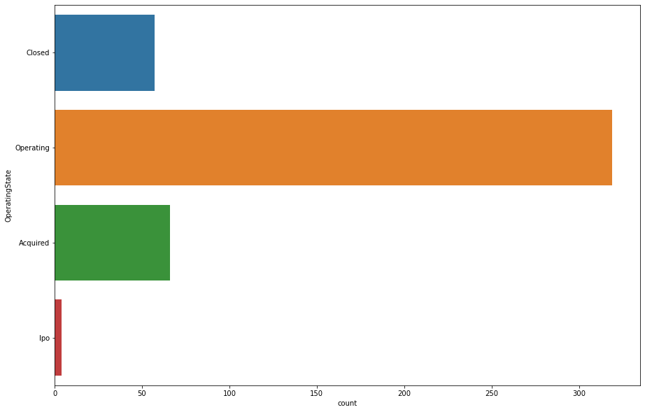

```python
#Using visualization - countplot for operating state feature
fig, ax = plt.subplots(figsize=(15, 10))
sns.countplot(y="OperatingState", data=dfa);
```

# Is there any significant difference between Funds raised by companies that are still operating vs companies that closed down?

```python
dfa.describe(include='all')
```

|  | Startup | Product | Funding | Event | Result | OperatingState | Funds_In_Millions |
| --- | --- | --- | --- | --- | --- | --- | --- |
| count | 446 | 446 | 4.460000e+02 | 446 | 446 | 446 | 446.000000 |
| unique | 446 | 446 | NaN | 26 | 5 | 4 | NaN |
| top | 3DLT | 3dlt.com | NaN | TC50 2008 | Contestant | Operating | NaN |
| freq | 1 | 1 | NaN | 31 | 312 | 319 | NaN |
| mean | NaN | NaN | 1.724149e+07 | NaN | NaN | NaN | 17.241489 |
| std | NaN | NaN | 9.048371e+07 | NaN | NaN | NaN | 90.483710 |
| min | NaN | NaN | 5.000000e+03 | NaN | NaN | NaN | 0.005000 |
| 25% | NaN | NaN | 7.452500e+05 | NaN | NaN | NaN | 0.745250 |
| 50% | NaN | NaN | 2.200000e+06 | NaN | NaN | NaN | 2.200000 |
| 75% | NaN | NaN | 9.475000e+06 | NaN | NaN | NaN | 9.475000 |
| max | NaN | NaN | 1.700000e+09 | NaN | NaN | NaN | 1700.000000 |

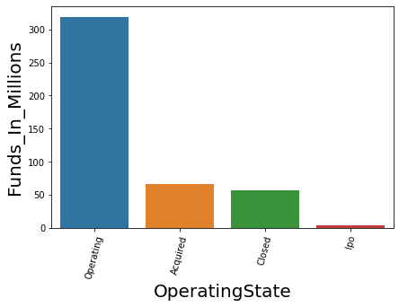

```python
Operatingstatus = dfc['OperatingState'].value_counts()

plt.figure(figsize=(15,10))
plt.subplot(221)
g = sns.barplot(x=Operatingstatus.index[:12],y=Operatingstatus.values[:12])
g.set_xticklabels(g.get_xticklabels(),rotation=75)
g.set_xlabel("OperatingState", fontsize=20)
g.set_ylabel("Funds_In_Millions", fontsize=20)
plt.show()
```

```python
#companies operating inclusing outliers
operating_with_o = dfa[dfa["OperatingState"] == 'Operating']
#operating compeanies exluding outliers
operating_without_o = Fund_without_o[Fund_without_o["OperatingState"] == 'Operating']

#companies closed including outliers
closed_with_o = dfa[dfa["OperatingState"] == 'Closed']
#closed companies exluding outliers
closed_without_o = Fund_without_o[Fund_without_o["OperatingState"] == 'Closed']
```

```python
#Case A is companies operating with the outliers

case_A = operating_with_o["Funds_In_Millions"]

#Case B is closed companies with the outliers

case_B = closed_with_o["Funds_In_Millions"]
```

# Write Null and alternate hypothesis 1. Null = the mean of both samples is same 2. Alternate = the mean is not same for both samples at 5% significance level or p_value < 0.05

```python
#using T test and finding the p-value
t_statistic, pvalue = ttest_ind(case_A, case_B)
print("The two sample T-test p value including the outliers = ", pvalue)
```

```
The two sample T-test p value including the outliers =  0.2557270186090243
```

```python
#Case c is companies operating without the outliers

case_C = operating_without_o["Funds_In_Millions"]

#Case d is closed companies without the outliers

case_D = closed_without_o["Funds_In_Millions"]
```

```python
#Computing the T test and finding the p-value
t_statistic, pvalue = ttest_ind(case_C, case_D)
print("The two sample T-test p value exluding outliers = ", pvalue)
```

```
The two sample T-test p value exluding outliers =  0.2557270186090243
```

# Hypothesis conclusion

Failed to reject null hypothesis as p-value is greater than type 1 error rate i.e. 0.05. There is not much difference in the mean funding amounts of the companies that are operating versus the ones that are closed

# Copy of original data frame

```python
Startups = df.copy()
Startups.head(10)
```

|  | Startup | Product | Funding | Event | Result | OperatingState |
| --- | --- | --- | --- | --- | --- | --- |
| 1 | 3DLT | 3dlt.com | $630K | Disrupt NYC 2013 | Contestant | Closed |
| 3 | 3Dprintler | 3dprintler.com | $1M | Disrupt NY 2016 | Audience choice | Operating |
| 5 | 5to1 | 5to1.com | $19.3M | TC50 2009 | Contestant | Acquired |
| 6 | 8 Securities | 8securities.com | $29M | Disrupt Beijing 2011 | Finalist | Operating |
| 10 | AdhereTech | adheretech.com | $1.8M | Hardware Battlefield 2014 | Contestant | Operating |
| 11 | AdRocket | adrocket.com | $1M | TC50 2008 | Contestant | Closed |
| 13 | Agrilyst | agrilyst.com | $1M | Disrupt SF 2015 | Winner | Operating |
| 14 | Aiden | aiden.ai | $750K | Disrupt London 2016 | Contestant | Operating |
| 15 | AirBoxLab | foobot.io | $17.9K | Hardware Battlefield 2014 | Contestant | Operating |
| 16 | Aircall | aircall.io | $11.6M | Disrupt SF 2015 | Contestant | Operating |

# Check frequency distribution of Result variable.

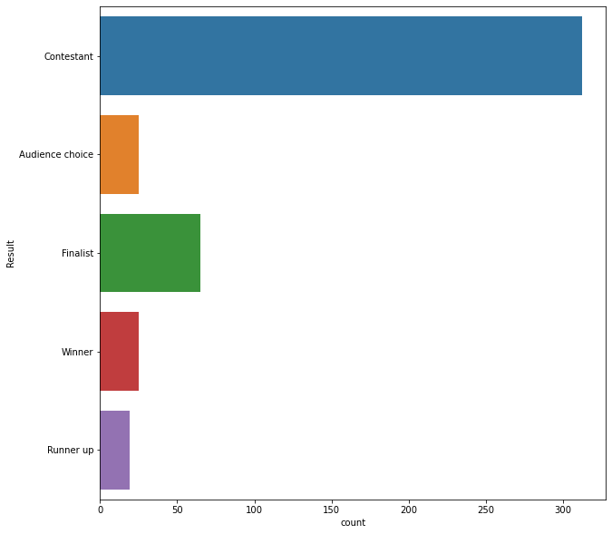

```python
fig, ax = plt.subplots(figsize=(10, 10))
sns.countplot(y="Result", data=Startups);
```